# Case Study 5 - SGD & SVM

**Team Members:** Amber Clark, Andrew Leppla, Jorge Olmos, Paritosh Rai

# Content

- Business Understanding
  - Scope
  - Introduction
  - Methods
  - Results
- Data Evaluation
  - Loading Data
  - Data Summary
  - Missing Values
  - Feature Removal
  - Exploratory Data Analysis (EDA)
- Model Preparations
  - Sampling & Scaling Data
  - Proposed Method
  - Evaluation Metrics
  - Feature Selection
- Model Building & Evaluations
  - Sampling Methodology
  - Model
  - Performance Analysis
- Model Interpretability & Explainability
  - Examining Feature Importance
- Conclusion
  - Final Model Proposal
  - Future Considerations, Model Enhancements and Alternative Modeling Approaches

# Business Understanding & Executive Summary

## Objective:

The goal of this case study is to build a Firewall classification model to automatically Allow or Deny access requests in real time with a high level of accuracy.

## Introduction:

This case study is about the management of firewall traffic. Cyber security consists of all the technologies and practices that keep computer systems and electronic data safe. A firewall is one of the most critical components in supporting big corporations to protect their data. The challenge offered to the team was to build a classification model that can automatically allow or deny the access request based on the features of the incoming request. A firewall is a hardware or software filter that authorizes access based on a certain set of pre-established rules. These rules are based on multiple aspects of packet data like their source, destination, content, protocol, and other data characteristics. When the network is significantly large, and policies are complicated, manual cross-check may be insufficient, inefficient, and ineffective in detecting anomalies. An automated model based on machine learning and high-performance computing methods is leveraged to detect anomalies to strengthen the firewall. To achieve this, firewall logs are analyzed, and the extracted features are fed to a set of machine learning classification algorithms.

Cybercrimes are increasing every day, which makes it critical that organizations build a robust system to ensure CPI (Customer Personal Information) and other confidential information is kept secure. Firewalls are one of the most critical tools to safeguard the network. Firewalls are like fencing to keep trespassers away and not allow unauthorized access to the system.

[figure not shown]

The efficiency and effectiveness of the firewall are judged by its accuracy and speed to identify malware and other suspicious activities. The firewall implementation can be done by hardware, software, and cloud. It carries out its function by filtering information at the application layer (proxy server) or permitting (or blocking) based on state, port, or protocol. Next-Generation Firewalls conduct deep packet inspection (beyond port/ protocol inspection). The most advanced firewalls are Unified Threat Management (UTM), which integrate multiple methodologies like stateful inspection, deep packet inspection, and Antivirus. The firewalls can provide advanced threat detection and mitigation by correlating ports, protocols, and/or suspicious behaviors. [1]

## Modeling:

The team used SVM (Support Vector Machine) and SGD (Stochastic Gradient Descent) classification algorithms to categorize the requests into Allowed or Denied.

SVM creates decision boundaries with a margin of separation for classification. Points on one side of the boundary are classified as Allowed, and points on the other side of the boundary are classified as Denied. Only the points near the decision boundaries and misclassifications are used to determine where the boundaries are ultimately placed. In this way, SVM is well suited to handle “gray areas” of classification where the two classes are more similar. These boundaries can be linear or nonlinear (i.e. linear, poly, rbf, sigmoid). Also, SVM is resistant to the effect of outliers as long as the outliers are on the correct side of the boundary.

The Stochastic Gradient Descent (SGD) classifier is a simple and efficient approach to fitting classifiers and regressors such as (linear) Support Vector Machines and Logistic Regression. These are very efficient and easy to implement. SGD should take a much shorter time to complete by minimizing the loss “stochastically”:

SGD works similarly to linear regression and logistic regression for classification. It requires regularization to prevent overfitting as well as hyperparameter tuning to optimize the algorithm for the best performance.

### Training and Test Split

The data were split into training and test sets using a 70/30 stratified split to ensure class balance in the training and test sets. Cross validation was not used because of the size of the dataset and the memory needed to train these models.

### Key Metrics

A range of models were explored using SVM and SGD Classifiers to tune the model hyperparameters. The key metrics the team focused on were maximizing **accuracy** while maintaining an acceptable **compute time** to identify the best model.

### Results

Below are the Confusion Matrices for the Training and Test sets for the final SGD model. The performance is consistent between training and testing sets, and the model predicts both classes with high accuracy.

Final SGD Train - Confusion Matrix:

|  | Predicted Denied | Predicted Allowed |
| --- | --- | --- |
| Actual Denied | 19,507 | 17 |
| Actual Allowed | 63 | 26,285 |

Final SGD Test - Confusion Matrix:

|  | Predicted Denied | Predicted Allowed |
| --- | --- | --- |
| Actual Denied | 8,361 | 7 |
| Actual Allowed | 23 | 11,269 |

### Feature Importance

Below are the coefficient values and a graph that maps each coefficient to its features, sorted in descending order. These coefficients represent the relative and not absolute importance. The top 3 features are Elapsed Time, NAT Destination port, and NAT Source Port, in that order.

[figure not shown]

## Conclusion

The accuracy obtained from the model could be considered very high at **>99.8%** for both the training and test sets. However, depending on how often the firewall has to deal with these requests, that may not be good enough for real-world application. If these requests were coming in at over 1000 per day, that would mean that 1-2 would be incorrectly classified, leading to an important blocked request or an unfortunate malicious attack getting through the firewall. The model could be further tuned such that more bad requests are blocked, but this would result in blocking more legitimate requests.

Methods used in this case study could be effective with High-Performance Computing (HPC) with multi-core processors to produce more comprehensive and accurate models. Also, more diligence can be done to reduce stochastic gradient descent to obtain minimum loss. The larger volume of data will also help enhance the learning leading to better performance of firewalls.

The quick convergence of these models in training could indicate that only a few important features and values contribute to the classification. Exploring the data showed that there were a few consistent variable values that always lead to a denied request, so if these are identified quickly in training, the rest of the data likely contributes minimal benefit to classification.

The team believes the model's performance is acceptable considering the requirements and time, however there's still room for improvement by further tuning the model, leveraging high performance computing and exploring other classification algorithms.

## Future Considerations

It is vital for companies to update firewall policies regularly and to continuously review the firewall logs, and retrain models accordingly on a regular cadence. This further supports the use of a faster model such as SGD.

# Data Evaluation

```python
# standard libraries
import pandas as pd
import numpy as np
#import re
import os
from IPython.display import Image
from abc import ABC, abstractmethod
import time
#import sklearn
#import time

# visualization
import seaborn as sns
import matplotlib.pyplot as plt
%matplotlib inline
from tabulate import tabulate
from IPython.display import clear_output
import xgboost

# data pre-processing
from scipy.io import arff
#from sklearn.model_selection import train_test_split
from sklearn.experimental import enable_iterative_imputer
from sklearn.impute import SimpleImputer, KNNImputer, IterativeImputer
from sklearn.impute._base import _BaseImputer
from sklearn.model_selection import StratifiedShuffleSplit
from sklearn.model_selection._split import BaseShuffleSplit
from sklearn.datasets import load_digits
from sklearn.preprocessing import MinMaxScaler, StandardScaler

# prediction models
from sklearn.svm import SVC
from sklearn.linear_model import SGDClassifier
from sklearn.svm._base import BaseSVC
from sklearn.model_selection import cross_val_score
from sklearn.metrics import f1_score
from sklearn.metrics import confusion_matrix
from sklearn.metrics import accuracy_score
from sklearn.metrics import precision_score
from sklearn.metrics import recall_score
from sklearn.metrics import fbeta_score

# import warnings filter
import warnings
warnings.filterwarnings('ignore')
from warnings import simplefilter
simplefilter(action='ignore', category=FutureWarning)
```

## Loading Data

```python
from os import listdir
from os.path import isfile, join

class FilePathManager:
    def __init__(self, local_dir: str):
        self.local_dir = local_dir

    def retrieve_full_path(self):
        return os.getcwd()+'/'+self.local_dir
```

```python
class Loader:
    df = pd.DataFrame()

    @abstractmethod
    def load_data(self, file_name):
        pass

    @abstractmethod
    def get_df(self):
        pass

    def size(self):
        return len(self.df)
```

```python
from typing import Callable

class CSVLoader(Loader):
    def __init__(self, file_path_manager: FilePathManager):
        self.file_path_manager = file_path_manager

    def load_data(self, _prepare_data: Callable[[pd.DataFrame], pd.DataFrame] = None):
        self.df = pd.read_csv(self.file_path_manager.retrieve_full_path())
        if _prepare_data:
            self.df = _prepare_data(self.df)

    def get_df(self):
        return self.df;

    def size(self):
        return len(self.df)
```

```python
def clean_data(df):
    data = df.copy()
    data.loc[ df['Action']!='allow', 'Action']='not allow'
    depandent = data['Action']
    depandent = (depandent=='allow').astype(int)
    data['Action']= depandent
    return data
```

```python
loader = CSVLoader(FilePathManager('log2.csv'))
loader.load_data(clean_data)
```

## Missing Values

**No missing values were identified in the dataset.**

```python
loader.get_df().info(verbose=True, null_counts=True)
```

```
<class 'pandas.core.frame.DataFrame'>
RangeIndex: 65532 entries, 0 to 65531
Data columns (total 12 columns):
 #   Column                Non-Null Count  Dtype
---  ------                --------------  -----
 0   Source Port           65532 non-null  int64
 1   Destination Port      65532 non-null  int64
 2   NAT Source Port       65532 non-null  int64
 3   NAT Destination Port  65532 non-null  int64
 4   Action                65532 non-null  int64
 5   Bytes                 65532 non-null  int64
 6   Bytes Sent            65532 non-null  int64
 7   Bytes Received        65532 non-null  int64
 8   Packets               65532 non-null  int64
 9   Elapsed Time (sec)    65532 non-null  int64
 10  pkts_sent             65532 non-null  int64
 11  pkts_received         65532 non-null  int64
dtypes: int64(12)
memory usage: 6.0 MB
```

## Feature Removal

The team explored different regularization methods for feature set optimization, for the best SVM model uses L2 regularization which prevents overfitting but does not help with feature reduction. The best SGD Model uses L1 regulartion and drops 6 features (Bytes, Bytes Sent, Bytes Received, Packets, pkts_sent, and pkts_received).

## Exploratory Data Analysis (EDA)

The provided dataset contains 65,532 rows and 12 columns. It includes the ports, bytes, and packet information along with elapsed time. The dataset will need no imputation as there are **no missing values**. The ‘Action’ response column identifies the requests that were Allowed or Denied. ‘Action’ with a designation, "deny", "drop", or "reset-both" was categorized as Denied and assigned a value of "0" (27,892 requests) and Allowed requests were assigned as "1" (37,640 requests). The Dataset is relatively balanced per the barchart below. However, the team decided to use stratified splitting for training and test in an abundance of caution. Also, the dataset will be scaled to bring the values into acceptable ranges for faster, more efficient modeling.

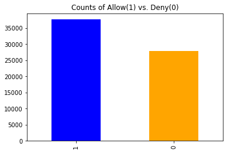

```python
df = loader.get_df()

count_Class=pd.value_counts(df['Action'], sort= True)
count_Class.plot(kind= 'bar', color= ["blue", "orange"])
plt.title('Counts of Allow(1) vs. Deny(0)')
plt.show()
```

All of the data (other than the target) are numeric, but not necessarily treated as continuous variables. As discussed in the introduction, ports represent a sort of address and are technically categorical features. However, many models can handle these port variables as continuous features which is discussed further below.

The Port features were explored for any relationships to the response variable. Both NAT Source and Destination Ports had clear separation of the class variable at Ports = 0 vs. Ports > 0.

[figure not shown]

The other numeric features were also examined with histograms. This was done to explore the scale and distribution of the features, as well as any relationships to the response variable. Note: features are plotted on a log scale to better visualize the highly skewed data. Elapsed Time (sec) showed the biggest separation of the target variable with Elapsed Time (sec) = 0 vs. Elapsed Time (sec) > 0.

[figure not shown]

# Model Preparations

SVM creates decision boundaries with a margin of separation for classification. Points on one side of the boundary are classified as Allowed, and points on the other side of the boundary are classified as Denied. Only the points near the decision boundaries and misclassifications are used to determine where the boundaries are ultimately placed. In this way, SVM is well suited to handle this “gray area” of classification where the two classes are more similar. These boundaries can be linear or nonlinear (i.e. linear, poly, rbf, sigmoid). Also, SVM is resistant to the effect of outliers as long as the outliers are on the correct side of the boundary.

The Stochastic Gradient Descent (SGD) classifier is a simple and efficient approach to fitting classifiers and regressors such as (linear) Support Vector Machines and Logistic Regression. These are very efficient and easy to implement. SGD should take a much shorter time to complete by minimizing the loss “stochastically”:

SGD works similarly to linear regression and logistic regression for classification. It requires regularization to prevent overfitting as well as hyperparameter tuning to optimize the algorithm for the best performance.

Training and test sets were created using a stratified splitting method to maintain the ratio of accepted versus denied requests. 30% of the data was withheld for the test set, and the relevant continuous features were normalized using StandardScaler.

The “port” categorical variables were considered for one hot encoding as dummy variables. The team attempted this and discovered that data would grow exponentially from 12 columns to over 27,000. The team dropped the encoded dummy variable proposal as it took a very long time to process the using SVM and SGD. The processing time is one of the critical measures along with the accuracy. Also, the team found that SVM and SGD algorithms are able to handle these categorical variables as continuous variables and still achieve consistent classification with a high accuracy.

## Sampling & Scaling Data

The class variables defined below include sampling and scaling.

```python
class BaseImputer:
    @abstractmethod
    def fit(self, X, y=None):
        pass

    @abstractmethod
    def transform(self, X):
        pass

class BaseModel:
    @abstractmethod
    def fit(self, X, y, sample_weight=None):
        pass

    @abstractmethod
    def predict(self, X):
        pass
```

```python
class Modeling:
    _X_train_fitted = None
    _X_test_fitted = None
    _y_train = None
    _y_test = None
    _y_preds = None

    def __init__(self, data: pd.DataFrame,
                 target_name: str,
                 shuffle_splitter: BaseShuffleSplit,
                 imputer: BaseImputer,
                 model: BaseModel, scaler = None):
        self._data = data
        self._target_name = target_name
        self._shuffle_splitter = shuffle_splitter
        self._imputer = imputer
        self._model = model
        self._X, self._y = self._split_data()
        self._scaler = scaler

    @property
    def X(self):
        return self._X

    @property
    def y(self):
        return self._y

    @property
    def model(self):
        return self._model

    @model.setter
    def model(self, model):
        self._model = model

    @property
    def X_train(self):
        return self._X_train_fitted

    @property
    def X_test(self):
        return self._X_test_fitted

    @property
    def y_train(self):
        return self._y_train

    @property
    def y_test(self):
        return self._y_test

    @property
    def y_preds(self):
        return self._y_preds

    def _split_data(self):
        X = self._data.copy()
        return X.drop([self._target_name], axis=1) , X[self._target_name]

    def _shuffle_split(self):
        X = self.X
        y = self.y
        for train_index, test_index in self._shuffle_splitter.split(X,y):
            X_train, X_test = X.iloc[train_index], X.iloc[test_index]
            y_train, y_test = y[train_index], y[test_index]
        return X_train, X_test, y_train, y_test

    def _fit_imputer(self, train):
        if self._imputer is not None:
            self._imputer.fit(train)

    def _fit_scaler(self, train):
        if self._scaler is not None:
            self._scaler.fit(train)

    def _impute_data(self, X: pd.DataFrame):
        if self._imputer is not None:
            return pd.DataFrame(self._imputer.transform(X), columns = self.X.columns, index = X.index)
        return X

    def _scale_data(self, X: pd.DataFrame):
        if self._scaler is not None:
            X = pd.DataFrame(self._scaler.transform(X), columns = self._X.columns)
        return X

    def prepare(self):
        X_train, X_test, y_train, y_test = self._shuffle_split()
        self._fit_imputer(X_train)
        X_train = self._impute_data(X_train)
        X_test = self._impute_data(X_test)
        self._fit_scaler(X_train)
        self._X_train_fitted = self._scale_data(X_train)
        self._X_test_fitted = self._scale_data(X_test)
        self._y_train = y_train
        self._y_test = y_test

    def prepare_and_train(self):
        self.prepare()
        return self.train()

    def train(self):
        self._model.fit(self.X_train, self.y_train)
        self._y_preds = self._model.predict(self.X_train)

        return self.metrics(self.y_train, self.y_preds)

    def test(self):
        return self.metrics(self.y_test, self._model.predict(self.X_test))

    @abstractmethod
    def metrics(self, y_true = None, y_pred = None):
        pass
```

## Proposed Method

```python
class ClassificationModeling(Modeling):
    def __init__(self,
                 data: pd.DataFrame,
                 target_name: str,
                 shuffle_splitter: BaseShuffleSplit,
                 imputer: BaseImputer,
                 model: BaseModel,
                 scaler = None,
                 beta: int = 1,
                 classification: str = 'binary'):
        super().__init__(data, target_name, shuffle_splitter, imputer, model, scaler)
        self.beta = beta
        self.classification = classification

    @abstractmethod
    def metrics(self, y_true = None, y_pred = None):
        pass
```

```python
from typing import Type, TypeVar

class SVMClassificationModeling(ClassificationModeling):
    TSVC = TypeVar("TSVC", bound=BaseSVC)
    all_models = [];

    def __init__(self,
             data: pd.DataFrame,
             target_name: str,
             shuffle_splitter: BaseShuffleSplit,
             imputer: BaseImputer,
             model: BaseModel,
             scaler = None,
             beta: int = 1,
             classification: str = 'binary'):
         super().__init__(data, target_name, shuffle_splitter, imputer, model, scaler, beta, classification)


    def parameter_tuning(self, params, class_to_instantiate: Type[TSVC]):
        list_of_models = []
        combination = []
        params_base = {}
        output = []
        for key, value in params.items():
            if isinstance(value, list):
                combination.append((key,value))
            else:
                params_base[key]=value

        result = SVMClassificationModeling.get_combinations(combination)

        for r in result:
            list_of_models.append(class_to_instantiate(**{**params_base, **r}))

        for a_model in list_of_models:
            self.model = a_model
            startTrain = time.time()
            train_metrics = self.train()
            endTrain = time.time()
            test_metrics = self.test()
            endTest = time.time()
            train_time = endTrain - startTrain
            test_time = endTest - endTrain
            output.append({'model': a_model, 'train_metrics': {**train_metrics,**{'elapsed_time':train_time}}, 'test_metrics': {**test_metrics,**{'elapsed_time':test_time}}})
        self.all_models = output
        return output

    def find_best_model(self):
        max_accuracy = self.all_models[0]['test_metrics']['accuracy']
        location = 0
        for indx, output_metrics in enumerate(self.all_models):
            if max_accuracy < output_metrics['test_metrics']['accuracy']:
                max_accuracy = output_metrics['test_metrics']['accuracy']
                location = indx
            elif max_accuracy == output_metrics['test_metrics']['accuracy']:
                if output_metrics['test_metrics']['elapsed_time'] < self.all_models[location]['test_metrics']['elapsed_time']:
                    location = indx

        return self.all_models[location]

    @staticmethod
    def get_combinations(tuples):
        length = len(tuples)
        if length > 1:
            total_params = []
            tuple_copy = tuples.copy()
            a_tuple = tuple_copy.pop(0)
            params_list = SVMClassificationModeling.get_combinations(tuple_copy)
            for value in a_tuple[1]:
                for a_params in params_list:
                    temp = { a_tuple[0]: value}
                    total_params.append({**temp, **a_params})
            return total_params
        else:
            params_list = []
            a_tuple =  tuples[0]
            for value in a_tuple[1]:
                temp = {}
                temp[a_tuple[0]] = value
                params_list.append(temp)
            return params_list


    def metrics(self, y_true = None, y_pred = None):
        if y_true is None and y_pred is None:
            y_true = self.y_train
            y_pred = self.y_preds
        return {'matrix': confusion_matrix(y_true, y_pred),
                'accuracy': round(accuracy_score(y_true, y_pred), 5),
                'precision': precision_score(y_true, y_pred, average=self.classification),
                'recall': recall_score(y_true, y_pred, average=self.classification),
                'f1': f1_score(y_true, y_pred)}
```

## Evaluation Metrics

A range of models were explored using SVM and SGD Classifiers to tune the model hyperparameters. Primarily focused on maximizing **accuracy** while maintaining an acceptable **compute time** were the team's evaluation **metrics** to identify the best model.

A range of models were explored using SVM and SGD Classifiers to tune the model hyperparameters. The key metrics the team focused on were maximizing **accuracy** while maintaining an acceptable **compute time** to identify the best model.

### Baseline Model

If the model allowed all requests through it would be 57.4% accurate but useless for security.

```python
loader.get_df()['Action'].value_counts(normalize=True)
```

```
1    0.574376
0    0.425624
Name: Action, dtype: float64
```

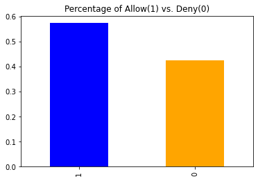

```python
count_Class=pd.value_counts(df['Action'], sort= True, normalize=True)
count_Class.plot(kind= 'bar', color= ["blue", "orange"])
plt.title('Percentage of Allow(1) vs. Deny(0)')
plt.show()
```

## Feature Selection

Regularization was used for feature selection with SGD. For SGD, L1, L2, and Elastic Net regularization were used to find the best model.

L1 regularization was used for the best model with SGD after dropping 6 features such that 5 features remained (Source Port, Destination Port, NAT Source Port, NAT Destination Port, and Elapsed Time).

For SVM, sklearn only uses L2 regularization which prevents overfitting but does not help with feature reduction, all features were used for the model.

# Model Building & Evaluations

## Modeling

### SVM

SVC = SVM Classification

```python
svc_classifier = SVMClassificationModeling(loader.get_df(),'Action',
                           StratifiedShuffleSplit(n_splits=1, test_size=0.3, random_state=12343),
                           None, # no imputation
                           SVC,
                           StandardScaler(), beta=2)
```

```python
svc_classifier.prepare()
```

```python
svc_results = svc_classifier.parameter_tuning({
'C': [0.005, 0.01, 0.05, 0.1, 0.2, 0.5, 1, 2, 10, 100],
'kernel': ['linear','rbf'],
'random_state':0
}, SVC)
```

#### The best SVM model was a nonlinear rbf model with C=100 (L2 regularization)

```python
svc_classifier.find_best_model() # default kernel='rbf'
```

```
{'model': SVC(C=100, random_state=0),
 'train_metrics': {'matrix': array([[19507,    17],
         [   75, 26273]]),
  'accuracy': 0.99799,
  'precision': 0.999353366298973,
  'recall': 0.9971534841354183,
  'f1': 0.9982522132299859,
  'elapsed_time': 3.393749237060547},
 'test_metrics': {'matrix': array([[ 8361,     7],
         [   28, 11264]]),
  'accuracy': 0.99822,
  'precision': 0.9993789370952001,
  'recall': 0.9975203684024088,
  'f1': 0.9984487878384967,
  'elapsed_time': 0.32436704635620117}}
```

#### Top 10 SVM Models sorted from highest to lowest accuracy

```python
svc_tuning = pd.DataFrame()
for result in svc_results:
    svc_tuning = svc_tuning.append({'kernel': result['model'].get_params()['kernel'],
                                    'C': result['model'].get_params()['C'],
                                   'Train Accuracy': result['train_metrics']['accuracy'],
                                   'Test Accuracy': result['test_metrics']['accuracy']},
                                   ignore_index=True)

svc_tuning.sort_values(by=['Train Accuracy','Test Accuracy'], ascending=False).head(10)
```

|  | C | Test Accuracy | Train Accuracy | kernel |
| --- | --- | --- | --- | --- |
| 19 | 100.0 | 0.99822 | 0.99799 | rbf |
| 17 | 10.0 | 0.99812 | 0.99789 | rbf |
| 8 | 0.2 | 0.99791 | 0.99771 | linear |
| 10 | 0.5 | 0.99791 | 0.99771 | linear |
| 14 | 2.0 | 0.99791 | 0.99765 | linear |
| 18 | 100.0 | 0.99807 | 0.99762 | linear |
| 12 | 1.0 | 0.99791 | 0.99760 | linear |
| 15 | 2.0 | 0.99797 | 0.99756 | rbf |
| 16 | 10.0 | 0.99791 | 0.99747 | linear |
| 13 | 1.0 | 0.99746 | 0.99721 | rbf |

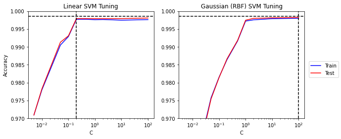

```python
fig, axes = plt.subplots(1, 2, figsize=(10, 4))

sns.lineplot(ax=axes[0], data = svc_tuning[svc_tuning['kernel']=='linear'], x='C', y='Train Accuracy', color='blue')
sns.lineplot(ax=axes[0], data = svc_tuning[svc_tuning['kernel']=='linear'], x='C', y='Test Accuracy', color='red')
axes[0].set_xscale('log')
axes[0].set_ylim(bottom=0.97, top=1)
axes[0].set_ylabel('Accuracy')
axes[0].set_title('Linear SVM Tuning')
axes[0].axvline(0.2, color='black', ls='--')
axes[0].axhline(0.9985,color='black',ls='--')

sns.lineplot(ax=axes[1], data = svc_tuning[svc_tuning['kernel']=='rbf'], x='C', y='Train Accuracy', color='blue')
sns.lineplot(ax=axes[1], data = svc_tuning[svc_tuning['kernel']=='rbf'], x='C', y='Test Accuracy', color='red')
axes[1].set_xscale('log')
axes[1].set_ylim(bottom=0.97, top=1)
axes[1].set_ylabel('')
axes[1].set_title('Gaussian (RBF) SVM Tuning')
axes[1].axvline(100, color='black', ls='--')
axes[1].axhline(0.9985,color='black',ls='--')

fig.legend(['Train','Test'], loc='center right')

#fig.tight_layout()
plt.show()
```

### Examine best linear model coefficients

The best Linear SVM model had C=0.2. Use this model to explore the SVM coefficients. There are no coefficients available with the less interpretable rgb model.

```python
svc_best_linear = SVMClassificationModeling(loader.get_df(),'Action',
                           StratifiedShuffleSplit(n_splits=1, test_size=0.3, random_state=12343),
                           None, # no imputation
                           SVC(kernel='linear', C=0.2, random_state=0),
                           StandardScaler(), beta=2)

svc_best_linear.prepare_and_train()
```

```
{'matrix': array([[19507,    17],
        [   88, 26260]]),
 'accuracy': 0.99771,
 'precision': 0.9993530463903795,
 'recall': 0.9966600880522241,
 'f1': 0.9980047505938243}
```

#### The top 2 linear coefficients were Elapsed Time (sec) and NAT Source Port.

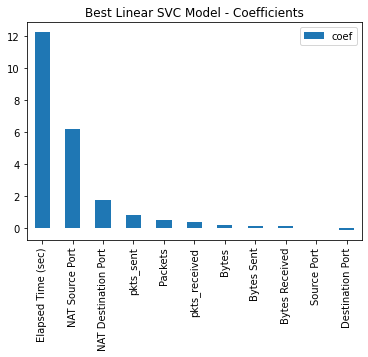

```python
svc_weights = pd.DataFrame(svc_best_linear.model.coef_[0], svc_best_linear.X.columns, columns=['coef']).sort_values('coef', ascending=False)
svc_weights.plot(kind='bar')
plt.title('Best Linear SVC Model - Coefficients')
plt.show()
```

### SVM Boundary Visualization

The Linear SVM Boundary, Margins, and Support Vectors were plotted with a simplifed 2-Term model that only included Elapsed Time (sec) and NAT Source Port. This was done to get insight into how the data were being separated and classified. The boundary is the solid black line, the margins are the dashed black lines, and the data points used as support vectors are circled. Again, data points within the margin and misclassified points are used as support vectors. Any points below the boundary line are classified as Denied, and any points above the boundary line are classified as Allowed.

[figure not shown]

### SGD

```python
sgd_classifier = SVMClassificationModeling(loader.get_df(),'Action',
                           StratifiedShuffleSplit(n_splits=1, test_size=0.3, random_state=12343),
                           None, # no imputation
                           SGDClassifier,
                           StandardScaler(), beta=2)
```

```python
sgd_classifier.prepare()
```

```python
sgd_results = sgd_classifier.parameter_tuning({
    "max_iter":1000,
    "loss" : ["hinge", "log", "squared_hinge", "modified_huber", "perceptron"],
    "alpha" : [0.0001, 0.001, 0.01, 0.1],
    "penalty" : ["l2", "l1", "elasticnet"],
    "random_state" : 0,
}, SGDClassifier)
```

```python
# Extract Accuracies into DataFrame and Display Top 10 Models
sgd_tuning = pd.DataFrame()
for result in sgd_results:
    sgd_tuning = sgd_tuning.append({'loss': result['model'].get_params()['loss'],
                                    'alpha': result['model'].get_params()['alpha'],
                                    'penalty': result['model'].get_params()['penalty'],
                                    'Train Accuracy': result['train_metrics']['accuracy'],
                                    'Test Accuracy': result['test_metrics']['accuracy']},
                                    ignore_index=True)

sgd_tuning.sort_values(by=['Test Accuracy','Train Accuracy'], ascending=False).head(10)
```

|  | Test Accuracy | Train Accuracy | alpha | loss | penalty |
| --- | --- | --- | --- | --- | --- |
| 49 | 0.99847 | 0.99826 | 0.0001 | perceptron | l1 |
| 1 | 0.99837 | 0.99819 | 0.0001 | hinge | l1 |
| 40 | 0.99837 | 0.99819 | 0.0010 | modified_huber | l1 |
| 37 | 0.99837 | 0.99802 | 0.0001 | modified_huber | l1 |
| 4 | 0.99822 | 0.99806 | 0.0010 | hinge | l1 |
| 48 | 0.99797 | 0.99802 | 0.0001 | perceptron | l2 |
| 54 | 0.99786 | 0.99791 | 0.0100 | perceptron | l2 |
| 2 | 0.99786 | 0.99762 | 0.0001 | hinge | elasticnet |
| 0 | 0.99776 | 0.99767 | 0.0001 | hinge | l2 |
| 13 | 0.99761 | 0.99743 | 0.0001 | log | l1 |

### Final Model

The best overall models were SGD models using L1 regularization with an alpha = 0.0001. The best overall model used this with the Perceptron loss function which acts like a single neuron in a neural network. The weights of the linear model are tuned based on this loss function that subtracts the target from the output of the perceptron. The activation of the perceptron is a binary step function which is set to one if the output of the linear model is greater than zero, else it is -1.

```python
final_model = sgd_classifier.find_best_model()
final_model
```

```
{'model': SGDClassifier(loss='perceptron', penalty='l1', random_state=0),
 'train_metrics': {'matrix': array([[19507,    17],
         [   63, 26285]]),
  'accuracy': 0.99826,
  'precision': 0.9993536613185309,
  'recall': 0.9976089266737513,
  'f1': 0.9984805318138651,
  'elapsed_time': 0.24972891807556152},
 'test_metrics': {'matrix': array([[ 8361,     7],
         [   23, 11269]]),
  'accuracy': 0.99847,
  'precision': 0.9993792124866974,
  'recall': 0.9979631597591215,
  'f1': 0.9986706841545552,
  'elapsed_time': 0.06569600105285645}}
```

## Model's Performance Analysis

SGD Train - Confusion Matrix:

|  | Predicted Denied | Predicted Allowed |
| --- | --- | --- |
| Actual Denied | 19,507 | 17 |
| Actual Allowed | 63 | 26,285 |

SGD Test - Confusion Matrix:

|  | Predicted Denied | Predicted Allowed |
| --- | --- | --- |
| Actual Denied | 8,361 | 7 |
| Actual Allowed | 23 | 11,269 |

The final SGD Classifier coefficients are given in the graph below. The L1 regularization eliminated all but 5 variables, with NAT Destination Port and Elapsed Time (sec) having the largest coefficients by far.

## Model Interpretability & Explainability

### Examining Feature Importance

Below are the coefficient values and a graph that maps each coefficient to its features, sorted in descending order. These coefficients represent the relative and not absolute importance. The top 3 features are Elapsed Time, NAT Destination port, and NAT Source Port, in that order.

```python
final_model['model'].coef_
```

```
array([[-1.08041419e-02, -1.70620975e-01,  4.99109556e-01,
         2.91573354e+01,  0.00000000e+00,  0.00000000e+00,
         0.00000000e+00,  0.00000000e+00,  3.03957719e+01,
         0.00000000e+00,  0.00000000e+00]])
```

```python
sgd_classifier.X.columns
```

```
Index(['Source Port', 'Destination Port', 'NAT Source Port',
       'NAT Destination Port', 'Bytes', 'Bytes Sent', 'Bytes Received',
       'Packets', 'Elapsed Time (sec)', 'pkts_sent', 'pkts_received'],
      dtype='object')
```

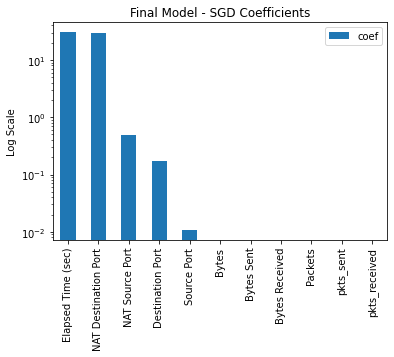

```python
weights = pd.DataFrame(abs(final_model['model'].coef_[0]), sgd_classifier.X.columns, columns=['coef']).sort_values('coef', ascending=False)
weights.plot(kind='bar')
plt.title('Final Model - SGD Coefficients')
plt.yscale('log')
plt.ylabel('Log Scale')
plt.show()
```

# Conclusion

The accuracy obtained from the model could be considered very high at **>99.8%** for both the training and test sets. However, depending on how often the firewall has to deal with these requests, that may not be good enough for real-world application. If these requests were coming in at over 1000 per day, that would mean that 1-2 would be incorrectly classified, leading to an important blocked request or an unfortunate malicious attack getting through the firewall. The model could be further tuned such that more bad requests are blocked, but this would result in blocking more legitimate requests.

Methods used in this case study could be effective with High-Performance Computing (HPC) with multi-core processors to produce more comprehensive and accurate models. Also, more diligence can be done to reduce stochastic gradient descent to obtain minimum loss. The larger volume of data will also help enhance the learning leading to better performance of firewalls.

The quick convergence of these models in training could indicate that only a few important features and values contribute to the classification. Exploring the data showed that there were a few consistent variable values that always lead to a denied request, so if these are identified quickly in training, the rest of the data likely contributes minimal benefit to classification.

The team believes the model's performance is acceptable considering the requirements and time, however there's still room for improvement by further tuning the model, leveraging high performance computing and exploring other classification algorithms.

### Future Considerations, Model Enhancements and Alternative Modeling Approaches

Reviewing other classification algorithms, including Naive Bayes, kNN, Decision Table, and HyperPipes may enhance the model. Based on the article by Erden Ucar & Erkan Ozhan, “ The Analysis of Firewall Policy Through Machine Learning and Data Mining,” published on May 17, 2017[3], KNN has shown some outstanding results. However, this would likely be a slow and inefficient model to predict in real time.

It is equally vital for the companies to update firewall policies regularly and continuously review the firewall logs, and retrain models accordingly on a regular cadence.

## References

[1] What Is Firewall: Types, How Does It Work & Advantages | Simplilearn

[2] Difference between IP address and Port Number. https://www.geeksforgeeks.org/difference-between-ip-address-and-port-number/

[3] The Analysis of Firewall Policy Through Machine Learning and Data Mining | SpringerLink (smu.edu)

## Appendix

### EDA Code

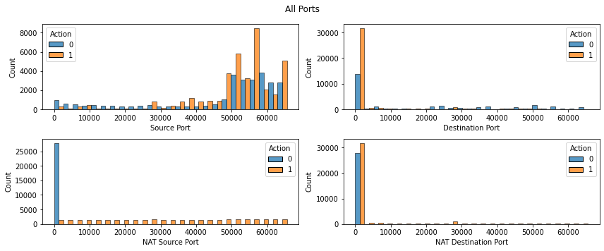

```python
rows = 2
cols = 2
port_vars = ['Source Port', 'Destination Port', 'NAT Source Port', 'NAT Destination Port']
cont_vars = list( set(df.columns) - set(port_vars) - set(['Action']) )
fig, axes = plt.subplots(rows, cols, figsize=(12, 5))
for i,j in zip( port_vars, range(len(port_vars)) ):
    sns.histplot(ax=axes[int(j/cols),j%cols], data = df, x=df[i], hue = 'Action',
                 bins=25, log_scale=[False,False], multiple='dodge')
    axes[int(j/cols),j%cols].set_xlabel(i)
    #axes[int(j/cols),j%cols].set_ylabel('Count (log scale)')
    #axes[int(j/cols),j%cols].set_ylim([0, 35000])

plt.suptitle('All Ports')
fig.tight_layout()
plt.show()
```

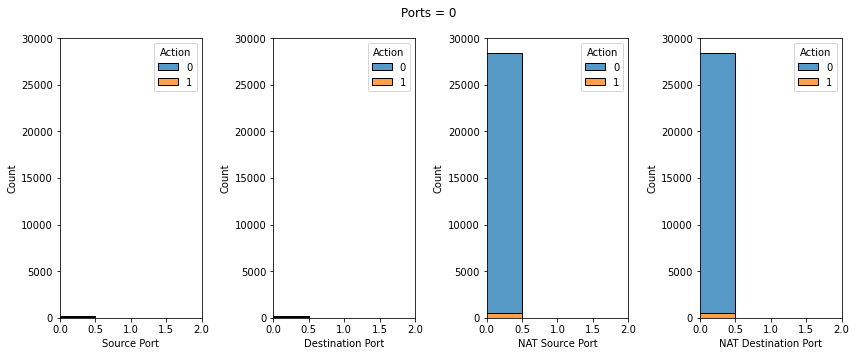

```python
rows = 1
cols = 4
fig, axes = plt.subplots(rows, cols, figsize=(12, 5))

for i,j in zip( port_vars, range(len(port_vars)) ):
    sns.histplot(ax=axes[j%cols], data = df, x=df[df[i]==0][i], hue = 'Action',
                 log_scale=[False,False], multiple='stack')
    axes[j%cols].set_xlabel(i)
    axes[j%cols].set_xlim([0, 2])
    axes[j%cols].set_ylim([0, 30000])
    #axes[j%cols].set_ylabel('Count (log scale)')

plt.suptitle('Ports = 0')
fig.tight_layout()
plt.show()
```

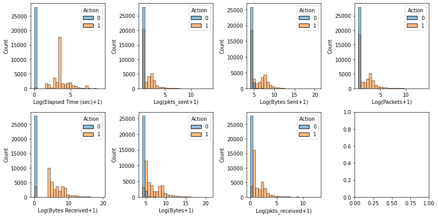

```python
rows = 2
cols = 4
fig, axes = plt.subplots(rows, cols, figsize=(12, 6))

for i,j in zip(cont_vars,range(len(cont_vars))):
    sns.histplot(ax=axes[int(j/cols),j%cols], data = df, x=np.log(df[i]+1), hue = 'Action', bins=25)
    axes[int(j/cols),j%cols].set_xlabel('Log('+i+'+1)')
    axes[int(j/cols),j%cols].set_ylabel('Count')

fig.tight_layout()
plt.show()
```

### Build SVM Linear Model with the Top 2 Coefficients to visualize the decision boundary in 2D

```python
top2_terms = [svc_weights.index[0], svc_weights.index[1]]
top2_terms.append('Action')

svc_best2_linear = SVMClassificationModeling(loader.get_df()[top2_terms],'Action',
                           StratifiedShuffleSplit(n_splits=1, test_size=0.3, random_state=12343),
                           None, # no imputation
                           SVC(kernel='linear', random_state=0),
                           StandardScaler(), beta=2)

svc_best2_linear.prepare_and_train()
top2_terms.pop();
```

```python
def plot_svc_linear_vectors(model, X, y):

    weights = pd.DataFrame(model.coef_[0], X.columns, columns=['coef']).sort_values('coef', ascending=False)

    # plot X data for Allow
    pos_class_index = np.where(y==1)
    plt.scatter(X.iloc[pos_class_index][weights.index[0]],
                X.iloc[pos_class_index][weights.index[1]],
                color='red', marker='x', label='Allow')

    # plot X data for Not Allow
    neg_class_index = np.where(y==0)
    plt.scatter(X.iloc[neg_class_index][weights.index[0]],
                X.iloc[neg_class_index][weights.index[1]],
                color='blue', marker='o', label='Not Allow')

    # add labels
    plt.xlabel('Scaled: ' + weights.index[0])
    plt.ylabel('Scaled: ' + weights.index[1])
    plt.legend(loc='upper left')

    # plot support vectors
    ax = plt.gca()
    ax.scatter(model.support_vectors_[:, X.columns.get_loc(weights.index[0])],
               model.support_vectors_[:, X.columns.get_loc(weights.index[1])],
               s=100, linewidth=0.2, facecolors='none', edgecolor='black')
```

```python
def plot_svc_decision_boundary(model, ax=None, plot_support=True):
    """Plot the decision function for a 2D SVC"""
    if ax is None:
        ax = plt.gca()
    xlim = ax.get_xlim()
    ylim = ax.get_ylim()

    # create grid to evaluate model
    x = np.linspace(xlim[0], xlim[1], 30)
    y = np.linspace(ylim[0], ylim[1], 30)
    Y, X = np.meshgrid(y, x)
    xy = np.vstack([X.ravel(), Y.ravel()]).T
    P = model.decision_function(xy).reshape(X.shape)

    # plot decision boundary and margins
    ax.contour(X, Y, P, colors='k',
               levels=[-1, 0, 1], alpha=0.5,
               linestyles=['--', '-', '--'])
```

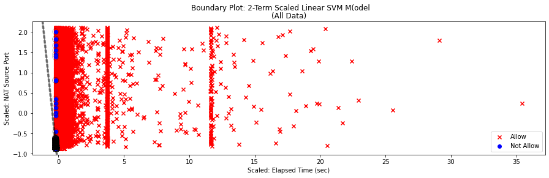

```python
plt.figure(figsize=(15,4))
plot_svc_linear_vectors(svc_best2_linear.model, svc_best2_linear.X_train, svc_best2_linear.y_train)
plot_svc_decision_boundary(svc_best2_linear.model)
plt.suptitle('Boundary Plot: 2-Term Scaled Linear SVM M(odel')
plt.title('(All Data)')
plt.legend(loc='lower right')
plt.show()
```

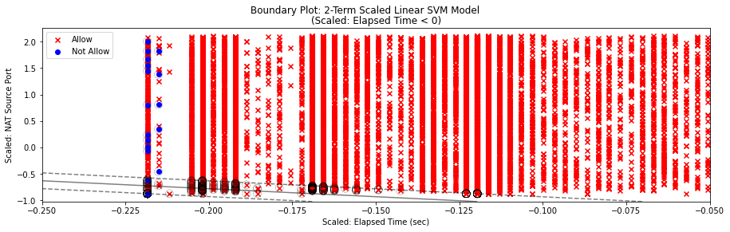

```python
plt.figure(figsize=(15,4))
plot_svc_linear_vectors(svc_best2_linear.model, svc_best2_linear.X_train, svc_best2_linear.y_train)
plot_svc_decision_boundary(svc_best2_linear.model)
plt.suptitle('Boundary Plot: 2-Term Scaled Linear SVM Model')
plt.title('(Scaled: Elapsed Time < 0)')
plt.xlim([-0.25, -0.05])
#plt.yscale('log')
plt.show()
```

### Make features >0 for log-scale plotting

```python
top2_terms.append('Action')

svc_best2_pos = SVMClassificationModeling(loader.get_df()[top2_terms],'Action',
                           StratifiedShuffleSplit(n_splits=1, test_size=0.3, random_state=12343),
                           None, # no imputation
                           SVC(kernel='linear', random_state=0),
                           MinMaxScaler(feature_range=(1,100)), beta=2)

svc_best2_pos.prepare_and_train()
top2_terms.pop();
```

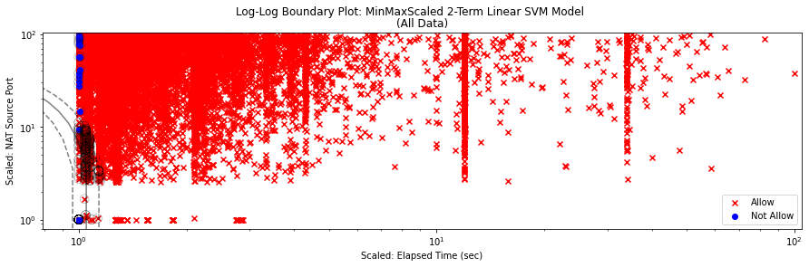

```python
plt.figure(figsize=(15,4))
plot_svc_linear_vectors(svc_best2_pos.model, svc_best2_pos.X_train, svc_best2_pos.y_train)
plot_svc_decision_boundary(svc_best2_pos.model)
plt.yscale('log')
plt.xscale('log')
#plt.xlim([0, 5])
plt.suptitle('Log-Log Boundary Plot: MinMaxScaled 2-Term Linear SVM Model')
plt.title('(All Data)')
plt.legend(loc='lower right')
plt.show()
```

### Visualize the 2D Decision Boundary for a Nonlinear (RGD) SVM Model

```python
top2_terms.append('Action')

svc_best2_rbf = SVMClassificationModeling(loader.get_df()[top2_terms],'Action',
                           StratifiedShuffleSplit(n_splits=1, test_size=0.3, random_state=12343),
                           None, # no imputation
                           SVC(kernel='rbf', C=100, random_state=0),
                           StandardScaler(), beta=2)

svc_best2_rbf.prepare_and_train()
top2_terms.pop();
```

```python
svc_best2_rbf.test()
```

```
{'matrix': array([[ 8361,     7],
        [   26, 11266]]),
 'accuracy': 0.99832,
 'precision': 0.9993790472811142,
 'recall': 0.9976974849450939,
 'f1': 0.9985375581653003}
```

```python
def plot_svc_vectors(model, X, y, top2_terms):
    # no weights with non-linear SVM, need to manually provide top 2 terms

    # plot X data for Allow
    pos_class_index = np.where(y==1)
    plt.scatter(X.iloc[pos_class_index][top2_terms[0]],
                X.iloc[pos_class_index][top2_terms[1]],
                color='red', marker='x', label='Allow')

    # plot X data for Not Allow
    neg_class_index = np.where(y==0)
    plt.scatter(X.iloc[neg_class_index][top2_terms[0]],
                X.iloc[neg_class_index][top2_terms[1]],
                color='blue', marker='o', label='Not Allow')

    # add labels
    plt.xlabel('Scaled: ' + top2_terms[0])
    plt.ylabel('Scaled: ' + top2_terms[1])
    plt.legend(loc='lower left')

    # plot support vectors
    ax = plt.gca()
    ax.scatter(model.support_vectors_[:, X.columns.get_loc(top2_terms[0])],
               model.support_vectors_[:, X.columns.get_loc(top2_terms[1])],
               s=100, linewidth=0.2, facecolors='none', edgecolor='black')
```

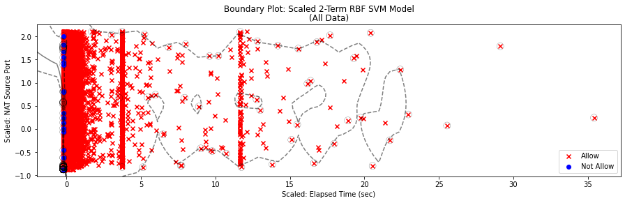

```python
plt.figure(figsize=(15,4))
plot_svc_vectors(svc_best2_rbf.model, svc_best2_rbf.X_train, svc_best2_rbf.y_train, top2_terms)
plot_svc_decision_boundary(svc_best2_rbf.model)
plt.suptitle('Boundary Plot: Scaled 2-Term RBF SVM Model')
plt.title('(All Data)')
plt.legend(loc='lower right')
plt.show()
```

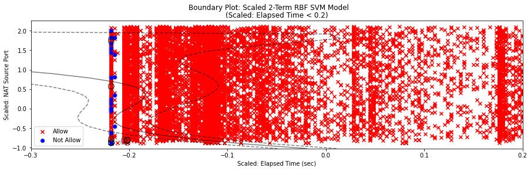

```python
plt.figure(figsize=(15,4))
plot_svc_vectors(svc_best2_rbf.model, svc_best2_rbf.X_train, svc_best2_rbf.y_train, top2_terms)
plot_svc_decision_boundary(svc_best2_rbf.model)
plt.xlim([-0.3, 0.2])
plt.suptitle('Boundary Plot: Scaled 2-Term RBF SVM Model')
plt.title('(Scaled: Elapsed Time < 0.2)')
plt.legend(loc='lower left')
plt.show()
```